# Benchmark: DMSO control selection

```r
suppressMessages(library(macpie))
suppressMessages(library(tibble))
suppressMessages(library(stringr))
suppressMessages(library(pheatmap))
suppressMessages(library(ggiraph))
suppressMessages(library(tidyseurat))
suppressMessages(library(purrr))
suppressMessages(library(ggplot2))
```

```r
options(scipen=999, digits=3)
```

## DRUGseq DMSO control selection

First we load the file of good DMSO control wells identified by the DRUGseq authors in their github repo.

Here, we show the good DMSO wells for batch 24, which contains the three plates we are interested in (VH02012942, VH02012944, VH02012956).

```r
good_DMSO_DRUGseq <- read.csv(paste0(dir, "DRUGseqData/robust_RC_ReferenceControl_DMSO_wells.txt"), sep="")
good_DMSO_DRUGseq %>% filter(batch_id==24) %>% select(batch_id, plate_barcode, well_id)
```

```
##   batch_id plate_barcode well_id
## 1       24    VH02012942     I23
## 2       24    VH02012942     M23
## 3       24    VH02012944     D23
## 4       24    VH02012944     H23
## 5       24    VH02012956     I23
## 6       24    VH02012956     J23
```

As from their results of good DMSO controls, these are the good DMSO wells for batch 24:

VH02012942: I23, M23

VH02012944: D23, H23

VH02012956: I23, J23

## macpie DMSO control selection

Now we will use a function `select_top_replicates_tmmcpm` to identify good DMSO controls from batch 24.

This function:

- applies CPM filtering,
- performs TMMwsp normalisation and computes log-CPM,
- ranks wells by their mean Fisher-z–transformed sample–sample correlation to all other wells (Pearson or Spearman)
- selects the top n wells (user-defined) as good controls.

```r
select_top_replicates_tmmcpm <- function(
  data,
  combined_id,                 # e.g. "CB_43_EP73_0"
  orig_ident,                  # e.g. "VH02012942"
  cpm_filter    = 1,           # CPM threshold for gene filtering
  min_samps     = 16,          # number of samples a gene must be expressed in
  corr_method   = c("spearman","pearson"),
  top_n         = 5,
  make_plots    = TRUE
){

  corr_method <- match.arg(corr_method)

  # Subset to the plate/condition of interest
  subgroup <- subset(data, subset = combined_id == !!combined_id & orig.ident == !!orig_ident)

  # Counts and human-friendly column names
  counts_d <- GetAssayData(subgroup, assay = "RNA", layer = "counts")
  well_colnames <- paste0(subgroup$orig.ident, "_", subgroup$Well_ID)
  names(well_colnames) <- rownames(subgroup@meta.data)
  colnames(counts_d) <- well_colnames[colnames(counts_d)]

  # edgeR container + gene filtering
  y <- edgeR::DGEList(counts_d, group = subgroup$orig.ident)
  keep <- rowSums(edgeR::cpm(y) > cpm_filter) >= min_samps
  y <- y[keep, , keep.lib.sizes = FALSE]

  # TMMwsp → log2-CPM
  y <- edgeR::calcNormFactors(y, method = "TMMwsp")
  log_cpm_tmm <- edgeR::cpm(y, log = TRUE, normalized.lib.sizes = TRUE)

  #  Long data for boxplot
  df_long <- as.data.frame(log_cpm_tmm) |>
    tibble::rownames_to_column(var = "gene") |>
    tidyr::pivot_longer(-gene, names_to = "sample", values_to = "log_cpm")

  if (make_plots) {
    # Boxplot
    print(
      ggplot2::ggplot(df_long, ggplot2::aes(x = sample, y = log_cpm)) +
        ggplot2::geom_boxplot(outlier.size = 0.5) +
        ggplot2::labs(x = "Sample", y = "log2 CPM",
                      title = "Boxplot of log2-CPM (TMMwsp)") +
        ggplot2::theme_classic() +
        ggplot2::theme(axis.text.x = ggplot2::element_text(angle = 45, hjust = 1))
    )
  }

  # Correlation matrices
  cors_pear  <- stats::cor(log_cpm_tmm, method = "pearson")
  cors_spear <- stats::cor(log_cpm_tmm, method = "spearman")

  if (make_plots) {
    pheatmap::pheatmap(cors_pear,  main = "Sample–sample correlation (Pearson, log2-CPM)")
    pheatmap::pheatmap(cors_spear, main = "Sample–sample correlation (Spearman, log2-CPM)")
  }

  # Ranking by mean Fisher-z correlation to all *other* samples
  R <- stats::cor(log_cpm_tmm, method = corr_method, use = "pairwise.complete.obs")
  diag(R) <- NA_real_

  # clip, Fisher z, average, back-transform
  Z <- atanh(pmin(pmax(R, -0.999999), 0.999999))
  score_z <- rowMeans(Z, na.rm = TRUE)
  score_r <- tanh(score_z)

  # top-N names and scores
  ord  <- order(score_r, decreasing = TRUE, na.last = NA)
  srt <- score_r[ord]
  cutoff <- srt[top_n]              # N-th best score
  keep   <- srt >= cutoff    # keep all tied at the cutoff
  topN <- srt[keep]

  # return everything useful
  list(
    subset_obj   = subgroup,
    dge          = y,
    log_cpm_tmm  = log_cpm_tmm,
    boxplot_df   = df_long,
    cor_pearson  = cors_pear,
    cor_spearman = cors_spear,
    ranking_method = corr_method,
    scores_mean_to_others = sort(score_r, decreasing = TRUE),
    topN = topN
  )
}
```

```r
# mac_filtered <- filter_genes_by_expression(as_mac,
#                 group_by = "combined_id", min_counts = 10,
#                 min_samples = min_sample_num)

# saveRDS(mac_filtered,
# file = paste0(dir, "DRUGseqData/macpie_filtered_batch24.Rds"))


mac_filtered <- readRDS(paste0(dir, "/DRUGseqData/macpie_filtered_batch24.Rds"))
```

```r
mac_filtered[["percent.mt"]] <- PercentageFeatureSet(mac_filtered, pattern = "^mt-|^MT-")
mac_filtered[["percent.ribo"]] <- PercentageFeatureSet(mac_filtered, pattern = "^Rp[slp][[:digit:]]|^Rpsa|^RP[SLP][[:digit:]]|^RPSA")
```

```r
mac_filtered$combined_id <- str_replace_all(mac_filtered$combined_id, "-","_")
```

### RLE plot

RLE plot to quickly visualise raw counts of DMSO wells in batch 24 plates

```
## tidyseurat says: Key columns are missing. A data frame is returned for independent data analysis.
```

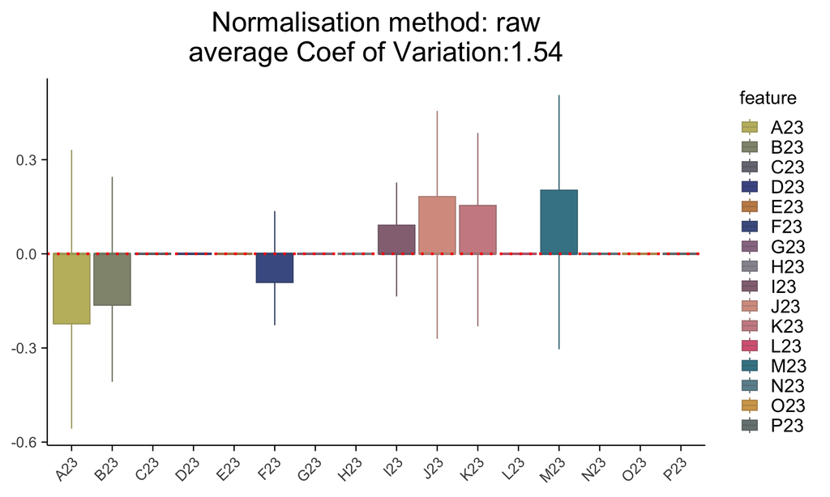

```r
# mac_filtered_cp <- mac_filtered %>% filter(combined_id %in% c("CB_43_EP73_0","FF_86_NH56_10"))
mac_filtered_cp <- mac_filtered %>% filter(combined_id %in% c("CB_43_EP73_0"))
plot_rle(subset(mac_filtered_cp, subset=orig.ident=="VH02012942"), label_column = "Well_ID", normalisation = "raw")
```

```
## tidyseurat says: Key columns are missing. A data frame is returned for independent data analysis.
```

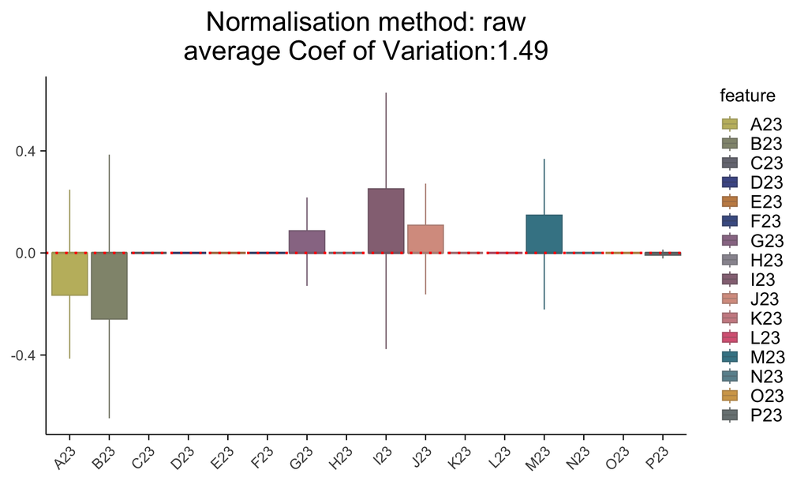

```r
plot_rle(subset(mac_filtered_cp, subset=orig.ident=="VH02012944"), label_column = "Well_ID", normalisation = "raw")
```

```
## tidyseurat says: Key columns are missing. A data frame is returned for independent data analysis.
```

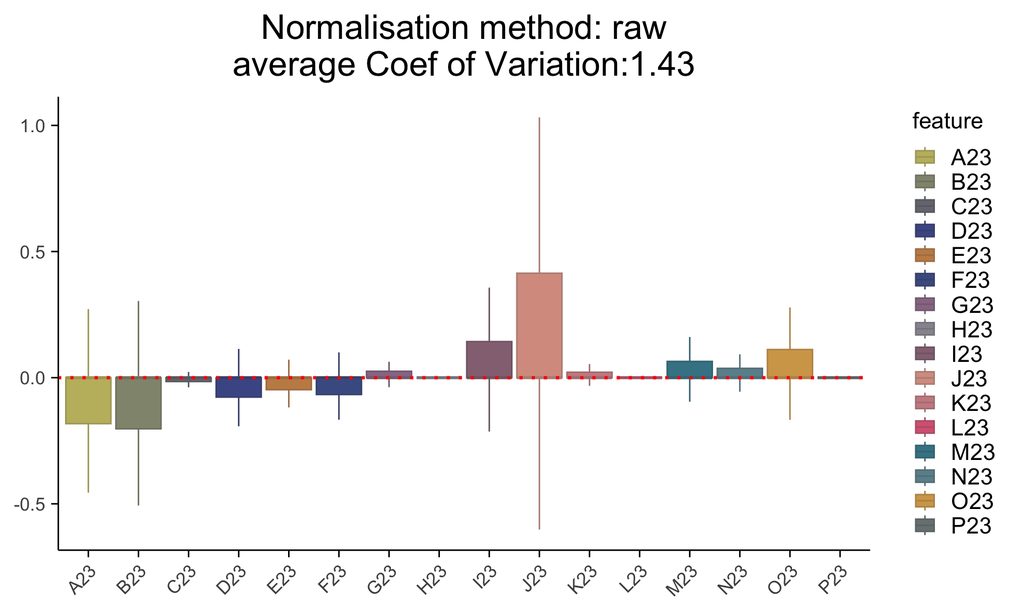

```r
plot_rle(subset(mac_filtered_cp, subset=orig.ident=="VH02012956"), label_column = "Well_ID", normalisation = "raw")
```

From the RLE plots above, we can see that there are some level of variation among DMSO wells in each plate. It’s important to select the best DMSO wells as controls for downstream analysis.

### Select good DMSO controls using macpie

Now we will apply the `select_top_replicates_tmmcpm` function to each of the three plates in batch 24 to identify good DMSO controls.

This function generates three plots:

- Boxplot of log2-CPM (TMMwsp)
- Sample–sample correlation (Pearson, log2-CPM)
- Sample–sample correlation (Spearman, log2-CPM)

These plots help to visualize the distribution of gene expression and the correlation between samples, aiding in the assessment of DMSO control quality.

#### Plate VH02012942

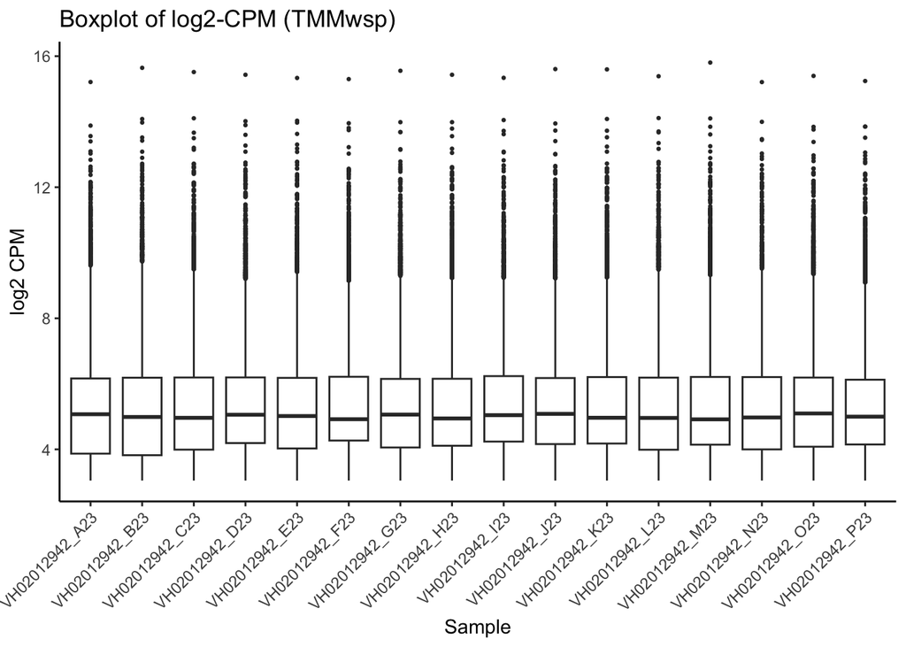

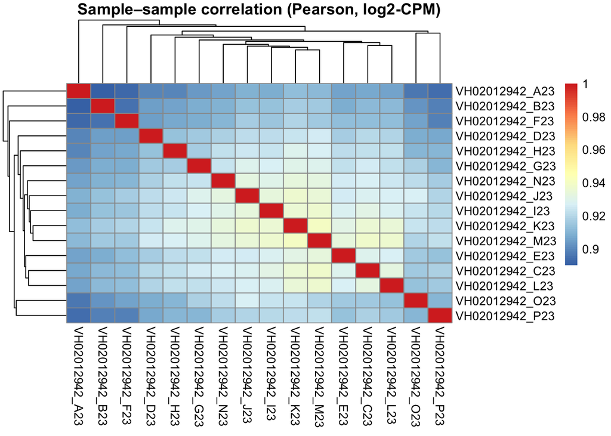

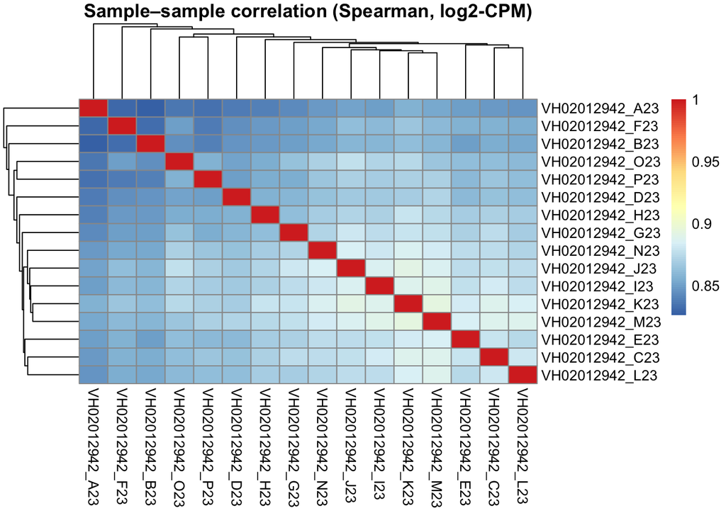

```r
dmso_VH02012942 <- select_top_replicates_tmmcpm(
  mac_filtered,
  combined_id = "CB_43_EP73_0",
  orig_ident  = "VH02012942",
  cpm_filter  = 1,
  min_samps   = 8,
  corr_method = "spearman",
  top_n       = 5,
  make_plots  = TRUE
)
```

Apart from the boxplot and correlation heatmaps, the function also returns a ranking of wells by their mean correlation to all other wells.

```r
dmso_VH02012942$scores_mean_to_others
```

```
## VH02012942_K23 VH02012942_M23 VH02012942_J23 VH02012942_I23 VH02012942_C23
##          0.878          0.877          0.875          0.874          0.872
## VH02012942_N23 VH02012942_L23 VH02012942_E23 VH02012942_G23 VH02012942_H23
##          0.870          0.869          0.869          0.866          0.863
## VH02012942_O23 VH02012942_D23 VH02012942_P23 VH02012942_F23 VH02012942_B23
##          0.860          0.858          0.858          0.851          0.849
## VH02012942_A23
##          0.843
```

Finally, it returns the top N wells as good DMSO controls.

```r
dmso_VH02012942$topN
```

```
## VH02012942_K23 VH02012942_M23 VH02012942_J23 VH02012942_I23 VH02012942_C23
##          0.878          0.877          0.875          0.874          0.872
```

Let’s repeat the same process for the other two plates in batch 24.

#### Plate VH02012944

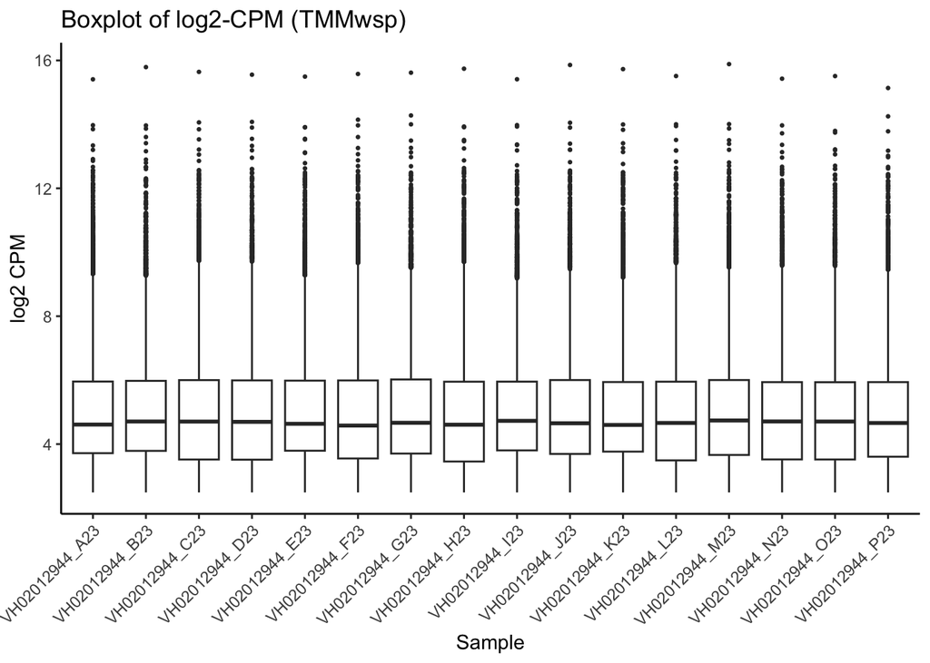

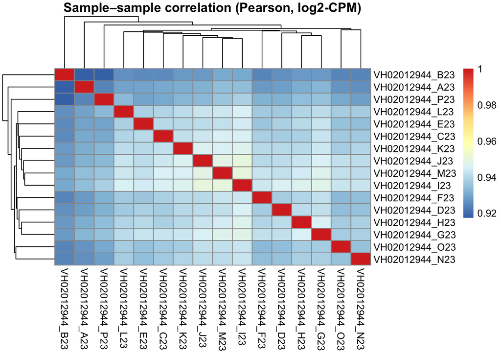

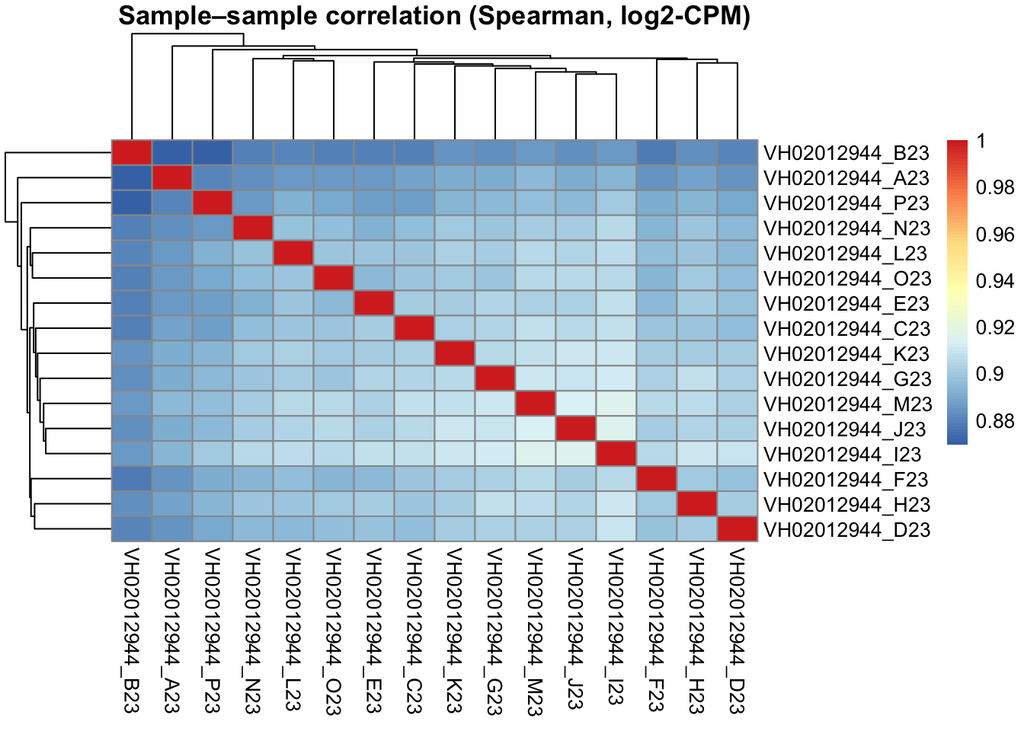

```r
dmso_VH02012944 <- select_top_replicates_tmmcpm(
  mac_filtered,
  combined_id = "CB_43_EP73_0",
  orig_ident  = "VH02012944",
  cpm_filter  = 1,
  min_samps   = 8,
  corr_method = "spearman",
  top_n       = 5,
  make_plots  = TRUE
)
```

```r
dmso_VH02012944$scores_mean_to_others
```

```
## VH02012944_I23 VH02012944_M23 VH02012944_J23 VH02012944_G23 VH02012944_K23
##          0.906          0.904          0.903          0.902          0.901
## VH02012944_H23 VH02012944_C23 VH02012944_L23 VH02012944_E23 VH02012944_D23
##          0.900          0.899          0.898          0.897          0.897
## VH02012944_O23 VH02012944_F23 VH02012944_N23 VH02012944_P23 VH02012944_A23
##          0.897          0.897          0.895          0.890          0.887
## VH02012944_B23
##          0.880
```

```r
dmso_VH02012944$topN
```

```
## VH02012944_I23 VH02012944_M23 VH02012944_J23 VH02012944_G23 VH02012944_K23
##          0.906          0.904          0.903          0.902          0.901
```

For plate VH02012944, the DRUGseq selected D23 and H23 DMSO wells are not in our top 5. However, H23 is ranked 6th by macpie, which is very close to the top 5.

#### Plate VH02012956

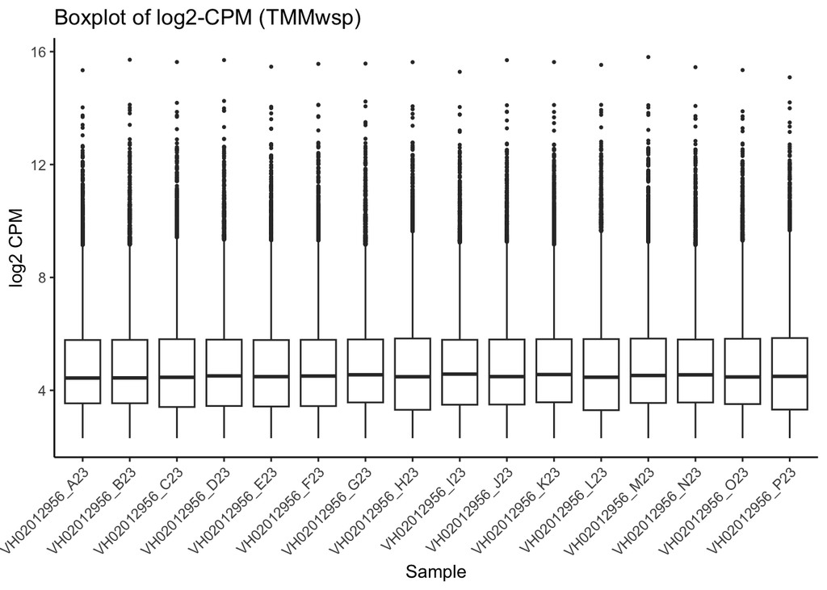

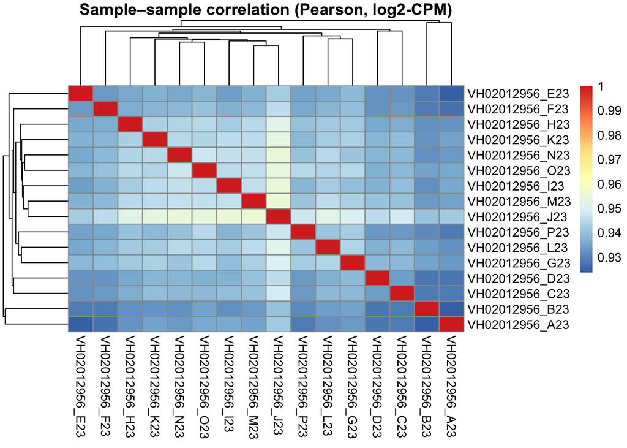

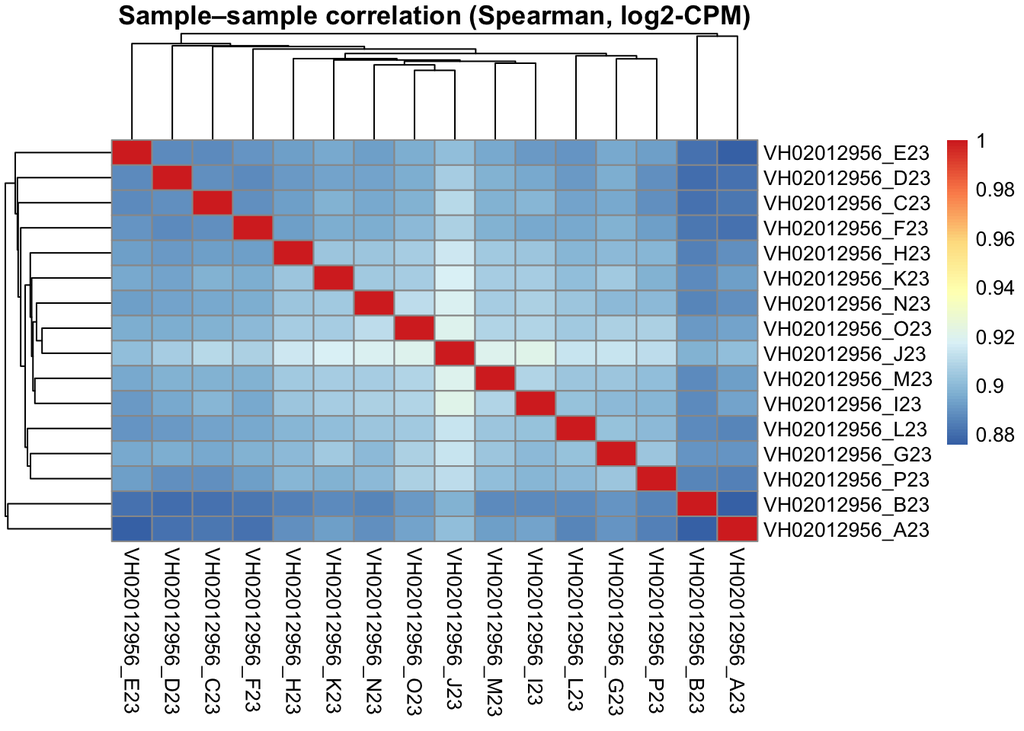

```r
dmso_VH02012956 <- select_top_replicates_tmmcpm(
  mac_filtered,
  combined_id = "CB_43_EP73_0",
  orig_ident  = "VH02012956",
  cpm_filter  = 1,
  min_samps   = 8,
  corr_method = "spearman",
  top_n       = 5,
  make_plots  = TRUE
)
```

```r
dmso_VH02012956$scores_mean_to_others
```

```
## VH02012956_J23 VH02012956_O23 VH02012956_M23 VH02012956_I23 VH02012956_K23
##          0.912          0.904          0.902          0.902          0.901
## VH02012956_N23 VH02012956_G23 VH02012956_H23 VH02012956_L23 VH02012956_P23
##          0.901          0.900          0.899          0.899          0.897
## VH02012956_F23 VH02012956_C23 VH02012956_D23 VH02012956_E23 VH02012956_A23
##          0.894          0.893          0.892          0.891          0.888
## VH02012956_B23
##          0.886
```

```r
dmso_VH02012956$topN
```

```
## VH02012956_J23 VH02012956_O23 VH02012956_M23 VH02012956_I23 VH02012956_K23
##          0.912          0.904          0.902          0.902          0.901
```

For plate VH02012956, the DRUGseq selected I23 and J23 DMSO wells are exactly the same as our top DMSO wells selected by macpie.

```r
library(peakRAM)
library(ps)
```

### Runtime and Memory

Now we will measure the runtime and memory usage of the `select_top_replicates_tmmcpm` function using the `peakRAM` package.

```r
res <- peakRAM({
  dmso_VH02012942 <- select_top_replicates_tmmcpm(
    mac_filtered,
    combined_id = "CB_43_EP73_0",
    orig_ident  = "VH02012942",
    cpm_filter  = 1,
    min_samps   = 8,
    corr_method = "spearman",
    top_n       = 5,
    make_plots  = FALSE
  )
  dmso_VH02012944 <- select_top_replicates_tmmcpm(
    mac_filtered,
    combined_id = "CB_43_EP73_0",
    orig_ident  = "VH02012944",
    cpm_filter  = 1,
    min_samps   = 8,
    corr_method = "spearman",
    top_n       = 5,
    make_plots  = FALSE
  )

  dmso_VH02012956 <- select_top_replicates_tmmcpm(
    mac_filtered,
    combined_id = "CB_43_EP73_0",
    orig_ident  = "VH02012956",
    cpm_filter  = 1,
    min_samps   = 8,
    corr_method = "spearman",
    top_n       = 5,
    make_plots  = FALSE
  )
  }
)

res
```

```
##                                                                                                                                                                                                                                                                                                          …
## 1 {dmso_VH02012942<-select_top_replicates_tmmcpm(mac_filtered,combined_id="CB_43_EP73_0",orig_ident="VH02012942",cpm_filter=1,min_samps=8,corr_method="spearman",top_n=5,make_plots=FALSE)dmso_VH02012944<-select_top_replicates_tmmcpm(mac_filtered,combined_id="CB_43_EP73_0",orig_ident="VH02012944",c…
##   Elapsed_Time_sec Total_RAM_Used_MiB Peak_RAM_Used_MiB
## 1             1.34                9.4               313
```

```r
if (!requireNamespace("ps", quietly = TRUE)) install.packages("ps")
get_rss_mb <- function() ps::ps_memory_info(ps::ps_handle())[1] / 1024^2

rss_before <- get_rss_mb()
tm <- system.time({
  dmso_VH02012942 <- select_top_replicates_tmmcpm(
    mac_filtered,
    combined_id = "CB_43_EP73_0",
    orig_ident  = "VH02012942",
    cpm_filter  = 1,
    min_samps   = 8,
    corr_method = "spearman",
    top_n       = 5,
    make_plots  = FALSE
  )
  dmso_VH02012944 <- select_top_replicates_tmmcpm(
    mac_filtered,
    combined_id = "CB_43_EP73_0",
    orig_ident  = "VH02012944",
    cpm_filter  = 1,
    min_samps   = 8,
    corr_method = "spearman",
    top_n       = 5,
    make_plots  = FALSE
  )

  dmso_VH02012956 <- select_top_replicates_tmmcpm(
    mac_filtered,
    combined_id = "CB_43_EP73_0",
    orig_ident  = "VH02012956",
    cpm_filter  = 1,
    min_samps   = 8,
    corr_method = "spearman",
    top_n       = 5,
    make_plots  = FALSE
  )
})
rss_after  <- get_rss_mb()
cat(sprintf("Elapsed: %.1fs | RSS before→after: %.0f→%.0f MiB (Δ %.0f MiB)\n",
            tm["elapsed"], rss_before, rss_after, rss_after - rss_before))
```

```
## Elapsed: 1.4s | RSS before→after: 2436→2431 MiB (Δ -5 MiB)
```

### Summary

In summary, for the three plates in batch 24, macpie successfully identified 4 out of 6 good DMSO wells that were also selected by the DRUGseq authors. Only for plate VH02012944, one of the DRUGseq selected DMSO wells (D23) was not in our top 5, but the other well (H23) was ranked 6th by macpie, which is very close to the top 5. This demonstrates that macpie is effective in selecting high-quality DMSO controls for downstream analysis without running permutation tests, making it a computationally efficient choice.

This function runs for each plate, it does not take into account any batches or plates. If it’s a cross-plates design, it is recommended to either compute within-plate or remove plate effects (e.g. using ComBat, limma removeBatchEffect functions) first.